# Nonlinear models

Author

Dr. Niloufar Abourashchi and Dr. Thomas Honnor

# Introduction

We have seen models of the form:
$$Y=β0+β1X$$
(Such models can be extended to include other covariates, but we are keeping things simple to start with.)

These can be considered to be linear models in two ways.

Firstly, they are linear in the covariates. That is, whatever the initial value of $X$, if I increase $X$ by $1$ then there will be a constant and consistent increase in $Y$ (of $β1$ for the equation above).

An example of a model which is nonlinear in the covariates is:
$$Y=β0+β1×log(X)$$
We have seen models like this occurring before, when we have considered transformations of covariates.

Secondly, the original model above is linear in the coefficients. That is, whatever the initial value of $β1$, if I increase $β1$ by $1$ then there will be a constant and consistent increase in $Y$ (of $X$ for the original equation above).

An example of a model which is nonlinear in the coefficients is:
$$Y=β0+Xβ1$$

The discussion today focuses specifically on nonlinear models of the first form – models which are linear in the coefficients but nonlinear in the covariates. A general expression for such models is:
$$Y=β0+β1f1(X)+β2f2(X)+...+βpfp(X)$$

# Example data

To gain insight into the concepts which we will explore, we’ll introduce the `Wage` dataset from the `ISLR` package.

```r
library(ISLR)
library(tidyverse)
```

```r
data(Wage)
str(Wage)
```

```
'data.frame':   3000 obs. of  11 variables:
 $ year      : int  2006 2004 2003 2003 2005 2008 2009 2008 2006 2004 ...
 $ age       : int  18 24 45 43 50 54 44 30 41 52 ...
 $ maritl    : Factor w/ 5 levels "1. Never Married",..: 1 1 2 2 4 2 2 1 1 2 ...
 $ race      : Factor w/ 4 levels "1. White","2. Black",..: 1 1 1 3 1 1 4 3 2 1 ...
 $ education : Factor w/ 5 levels "1. < HS Grad",..: 1 4 3 4 2 4 3 3 3 2 ...
 $ region    : Factor w/ 9 levels "1. New England",..: 2 2 2 2 2 2 2 2 2 2 ...
 $ jobclass  : Factor w/ 2 levels "1. Industrial",..: 1 2 1 2 2 2 1 2 2 2 ...
 $ health    : Factor w/ 2 levels "1. <=Good","2. >=Very Good": 1 2 1 2 1 2 2 1 2 2 ...
 $ health_ins: Factor w/ 2 levels "1. Yes","2. No": 2 2 1 1 1 1 1 1 1 1 ...
 $ logwage   : num  4.32 4.26 4.88 5.04 4.32 ...
 $ wage      : num  75 70.5 131 154.7 75 ...
```

```r
glimpse(Wage)
```

```
Rows: 3,000
Columns: 11
$ year       <int> 2006, 2004, 2003, 2003, 2005, 2008, 2009, 2008, 2006, 2004,…
$ age        <int> 18, 24, 45, 43, 50, 54, 44, 30, 41, 52, 45, 34, 35, 39, 54,…
$ maritl     <fct> 1. Never Married, 1. Never Married, 2. Married, 2. Married,…
$ race       <fct> 1. White, 1. White, 1. White, 3. Asian, 1. White, 1. White,…
$ education  <fct> 1. < HS Grad, 4. College Grad, 3. Some College, 4. College …
$ region     <fct> 2. Middle Atlantic, 2. Middle Atlantic, 2. Middle Atlantic,…
$ jobclass   <fct> 1. Industrial, 2. Information, 1. Industrial, 2. Informatio…
$ health     <fct> 1. <=Good, 2. >=Very Good, 1. <=Good, 2. >=Very Good, 1. <=…
$ health_ins <fct> 2. No, 2. No, 1. Yes, 1. Yes, 1. Yes, 1. Yes, 1. Yes, 1. Ye…
$ logwage    <dbl> 4.318063, 4.255273, 4.875061, 5.041393, 4.318063, 4.845098,…
$ wage       <dbl> 75.04315, 70.47602, 130.98218, 154.68529, 75.04315, 127.115…
```

There are a variety of choices for potential outcomes ($Y$) and covariates ($X$), but we decide here to focus on how an individual’s `wage` can be modelled using the individual’s `age`.

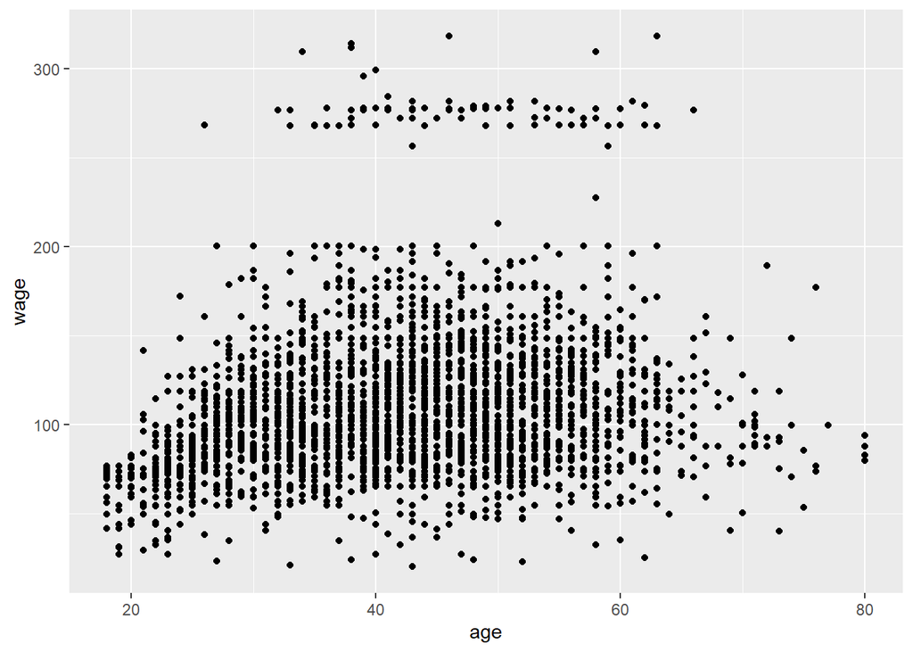

```r
Wage %>%
  ggplot(aes(y=wage, x=age)) +
    geom_point()
```

# Linear model

We might begin by fitting a linear regression model:
$$wage=β0+β1×age$$

```r
lm_1 <- lm(wage~age, data=Wage)
summary(lm_1)
```

```
Call:
lm(formula = wage ~ age, data = Wage)

Residuals:
     Min       1Q   Median       3Q      Max
-100.265  -25.115   -6.063   16.601  205.748

Coefficients:
            Estimate Std. Error t value Pr(>|t|)
(Intercept) 81.70474    2.84624   28.71   <2e-16 ***
age          0.70728    0.06475   10.92   <2e-16 ***
---
Signif. codes:  0 '***' 0.001 '**' 0.01 '*' 0.05 '.' 0.1 ' ' 1

Residual standard error: 40.93 on 2998 degrees of freedom
Multiple R-squared:  0.03827,   Adjusted R-squared:  0.03795
F-statistic: 119.3 on 1 and 2998 DF,  p-value: < 2.2e-16
```

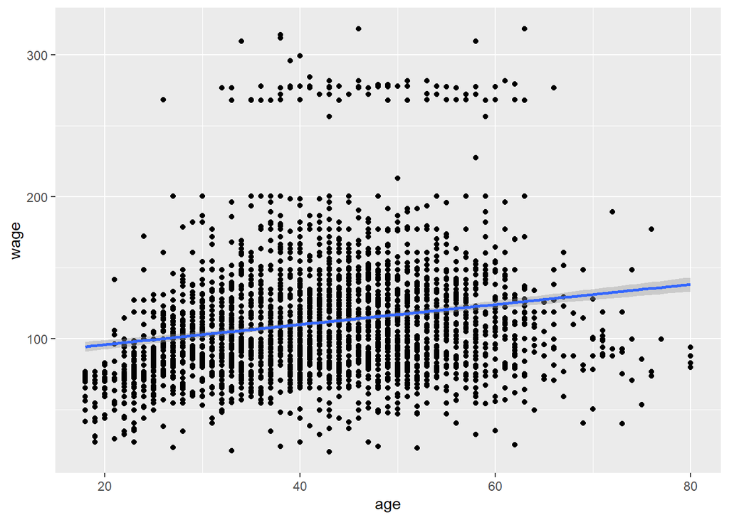

```r
Wage %>%
  ggplot(aes(y=wage, x=age)) +
    geom_point() +
    geom_smooth(method=lm)
```

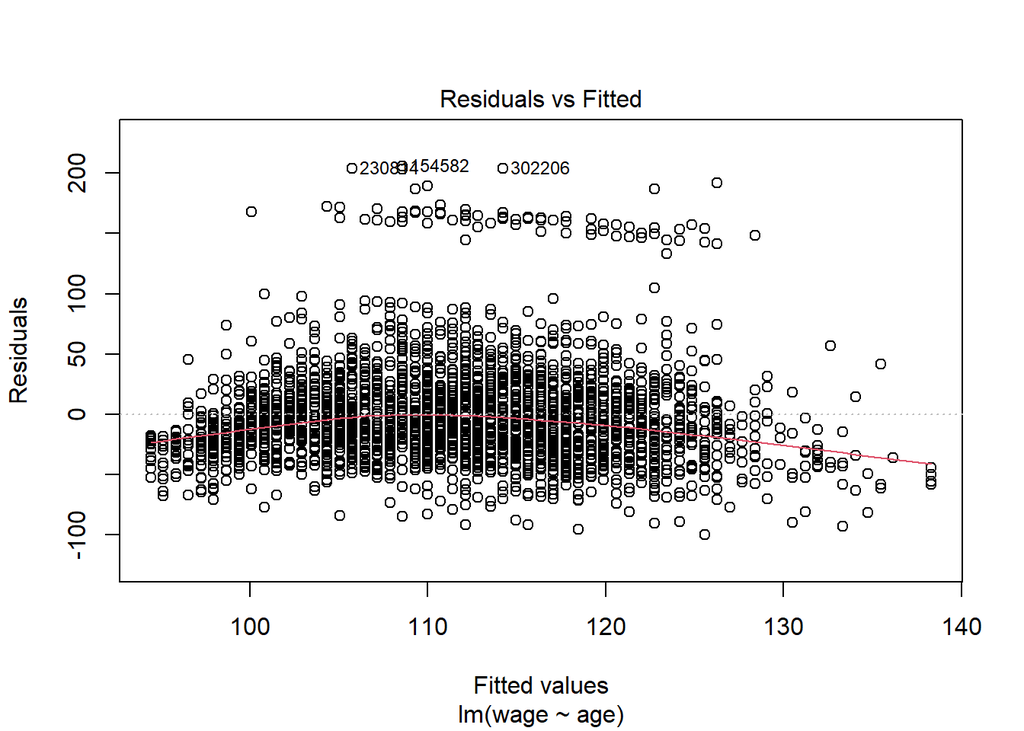

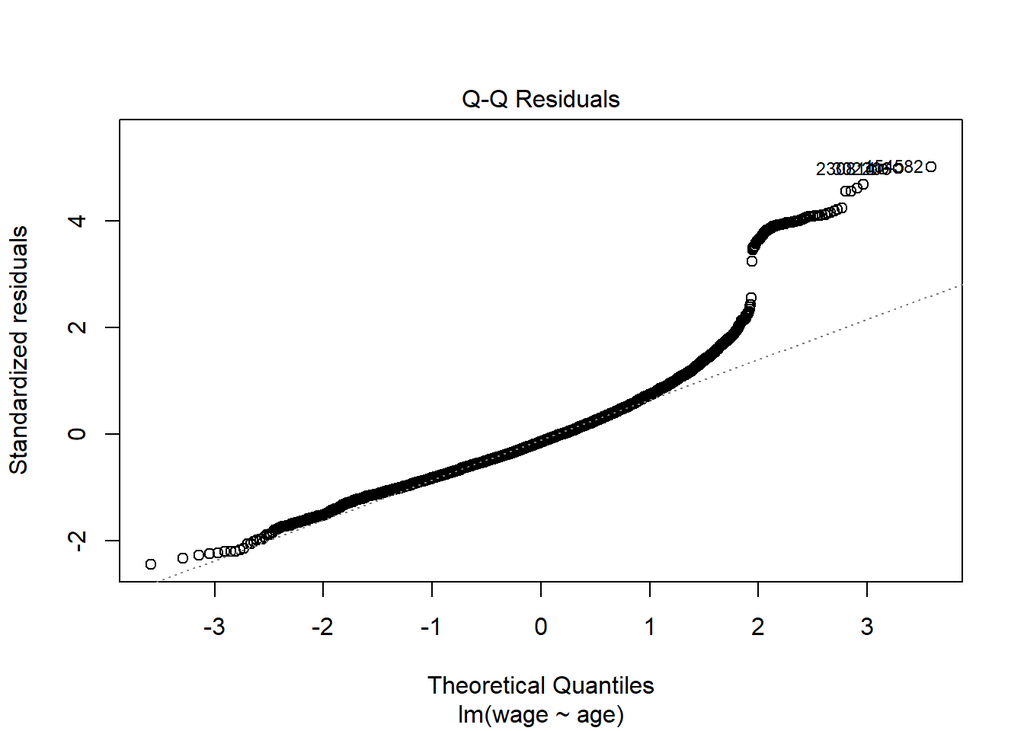

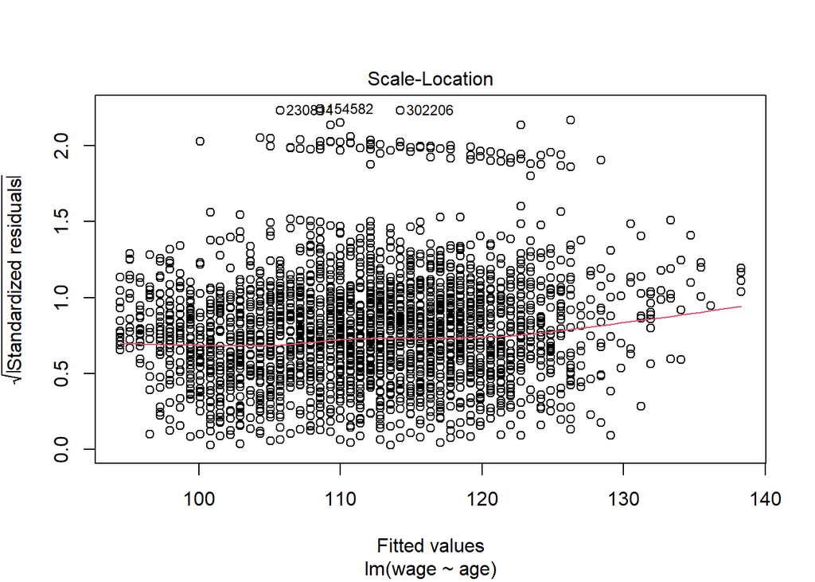

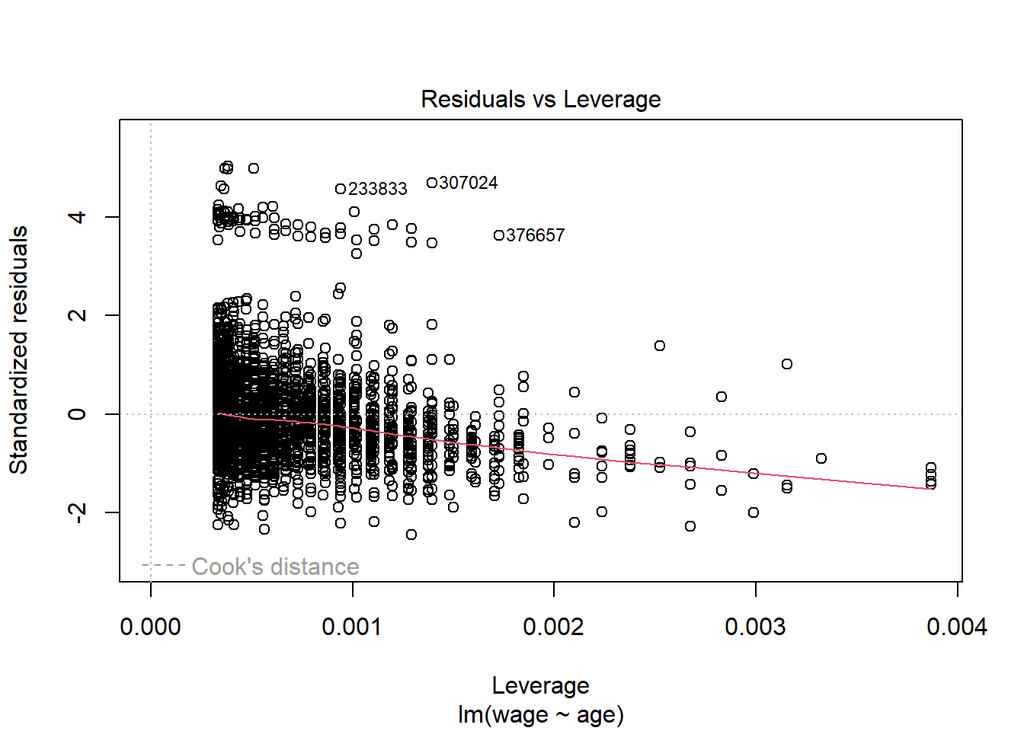

```r
plot(lm_1)
```

The numerical output indicates to us that every year a person ages, they are expected to increase their wage by $707.28$. How reasonable does this seem from looking at the plot of the regression line and the diagnostic plots for the model?

The plot of the regression line appears to show the data in an “upside down u-shape” pattern. Rather than `wage` increasing linearly with `age`, it appears that `wage` increases with `age` up to a certain point, after which the relationship reverses and `wage` starts to decrease with `age`. The same pattern can be seen in the residuals vs fitted values plot.

The behaviour displayed by the data is not necessarily unexpected. As younger adults gain experience of the workplace they gain skills (and associated promotions) which generally lead them to earn more money. Age discrimination might limit the job opportunities available to older individuals, reducing their access to higher paying jobs, or older individuals may take on part time/casualised work as they have already built up sufficient savings or to work around potential health conditions.

# Polynomial regression

An alternative possibility might be to build a nonlinear model for `wage` using polynomial functions of `age`. That is, build a model of the form:
$$wage=β0+β1×age+β2×age2+β3×age3+...+βp×agep$$

## First order polynomial

The order of a polynomial is the maximum power to which the variable is raised. In that sense, the linear model considered above is exactly a first order polynomial model.

## Second order polynomial

The “upside down u-shape” picture observed in the previous plots is similar to the shape formed by a quadratic relationship (powers of $x$ up to $2$) with a negative second derivative (the coefficient $β2$ of $x2$ is negative). We can test such a model for this data.

```r
lm_2 <- lm(wage~poly(age,2), data=Wage)
summary(lm_2)
```

```
Call:
lm(formula = wage ~ poly(age, 2), data = Wage)

Residuals:
    Min      1Q  Median      3Q     Max
-99.126 -24.309  -5.017  15.494 205.621

Coefficients:
               Estimate Std. Error t value Pr(>|t|)
(Intercept)    111.7036     0.7302  152.99   <2e-16 ***
poly(age, 2)1  447.0679    39.9926   11.18   <2e-16 ***
poly(age, 2)2 -478.3158    39.9926  -11.96   <2e-16 ***
---
Signif. codes:  0 '***' 0.001 '**' 0.01 '*' 0.05 '.' 0.1 ' ' 1

Residual standard error: 39.99 on 2997 degrees of freedom
Multiple R-squared:  0.08209,   Adjusted R-squared:  0.08147
F-statistic:   134 on 2 and 2997 DF,  p-value: < 2.2e-16
```

The coefficient of $age2$, $β2$, is statistically significantly different from $0$, indicating to us that the inclusion of $age2$ makes a valuable contribution to the model.

Likewise, the adjusted $R2$ for this model ($0.08147$) is greater than for the previous model ($0.03795$), supporting the inclusion of the $age2$ term.

```r
AIC(lm_1)
```

```
[1] 30788.67
```

```r
AIC(lm_2)
```

```
[1] 30650.8
```

Likewise, the [AIC](https://en.wikipedia.org/wiki/Akaike_information_criterion) for this model ($30650.8$) is lower than for the previous model ($30788.67$), supporting the inclusion of the $age2$ term.

```r
library(cvTools)
```

```r
set.seed(1)
cv_1 <- cvFit(lm_1,data=Wage,y=Wage$wage,K=5,R=20)
print(c(cv_1$cv,cv_1$se))
```

```
         CV          CV
40.94020518  0.01309962
```

```r
cv_2 <- cvFit(lm_2,data=Wage,y=Wage$wage,K=5,R=20)
print(c(cv_2$cv,cv_2$se))
```

```
       CV        CV
40.012848  0.017475
```

Likewise, the cross validation error for this model ($40.01$ with a standard error of $0.017$) is lower than for the previous model ($40.94$ with a standard error of $0.013$), supporting the inclusion of the $age2$ term.

We can plot the predicted values for the second order polynomial model by first generating a grid of `age` values to predict at, then pairing each with the corresponding predicted value of `wage`.

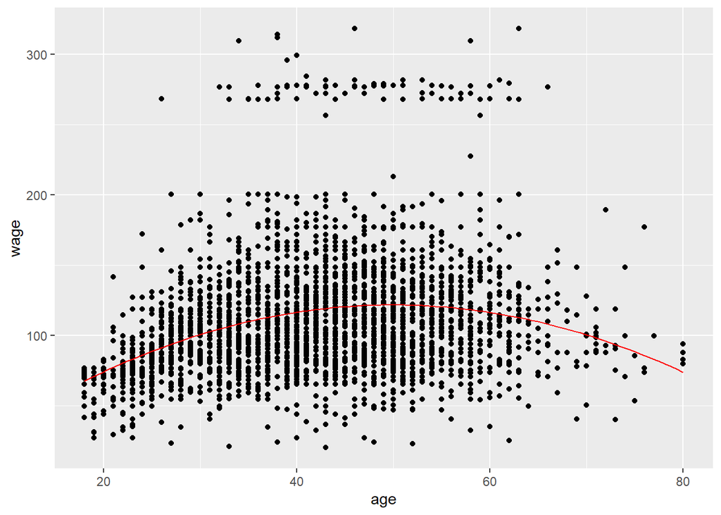

```r
age_grid <- seq(from=min(Wage$age),to=max(Wage$age),length.out=100)
age_grid_df <- tibble(age=age_grid)
age_grid_df$wage_predicted <- predict(lm_2,newdata=age_grid_df)

Wage %>%
  ggplot(aes(y=wage, x=age)) +
    geom_point() +
    geom_line(data=age_grid_df,
              mapping=aes(y=wage_predicted,x=age),
              color="red")
```

## Third order polynomial

If the second order polynomial model was an improvement over the linear model (a first order polynomial model), perhaps a third order polynomial model (aka a cubic model) is even better.

```r
lm_3 <- lm(wage~poly(age,3), data=Wage)
summary(lm_3)
```

```
Call:
lm(formula = wage ~ poly(age, 3), data = Wage)

Residuals:
    Min      1Q  Median      3Q     Max
-99.693 -24.562  -5.222  15.096 206.119

Coefficients:
               Estimate Std. Error t value Pr(>|t|)
(Intercept)    111.7036     0.7291 153.211  < 2e-16 ***
poly(age, 3)1  447.0679    39.9335  11.195  < 2e-16 ***
poly(age, 3)2 -478.3158    39.9335 -11.978  < 2e-16 ***
poly(age, 3)3  125.5217    39.9335   3.143  0.00169 **
---
Signif. codes:  0 '***' 0.001 '**' 0.01 '*' 0.05 '.' 0.1 ' ' 1

Residual standard error: 39.93 on 2996 degrees of freedom
Multiple R-squared:  0.0851,    Adjusted R-squared:  0.08419
F-statistic: 92.89 on 3 and 2996 DF,  p-value: < 2.2e-16
```

The coefficient of $age3$, $β3$, is statistically significantly different from $0$, indicating to us that the inclusion of $age3$ makes a valuable contribution to the model.

Likewise, the adjusted $R2$ for this model ($0.08419$) is greater than for the previous model ($0.08147$), supporting the inclusion of the $age3$ term.

```r
AIC(lm_2)
```

```
[1] 30650.8
```

```r
AIC(lm_3)
```

```
[1] 30642.92
```

Likewise, the AIC for this model ($30642.92$) is lower than for the previous model ($30650.8$), supporting the inclusion of the $age3$ term.

```r
set.seed(1)
print(c(cv_2$cv,cv_2$se))
```

```
       CV        CV
40.012848  0.017475
```

```r
cv_3 <- cvFit(lm_3,data=Wage,y=Wage$wage,K=5,R=20)
print(c(cv_3$cv,cv_3$se))
```

```
         CV          CV
39.95162176  0.01900926
```

Likewise, the cross validation error for this model ($39.95$ with a standard error of $0.019$) is lower than for the previous model ($40.01$ with a standard error of $0.017$), supporting the inclusion of the $age3$ term.

We can also plot the predicted values for the third order polynomial model.

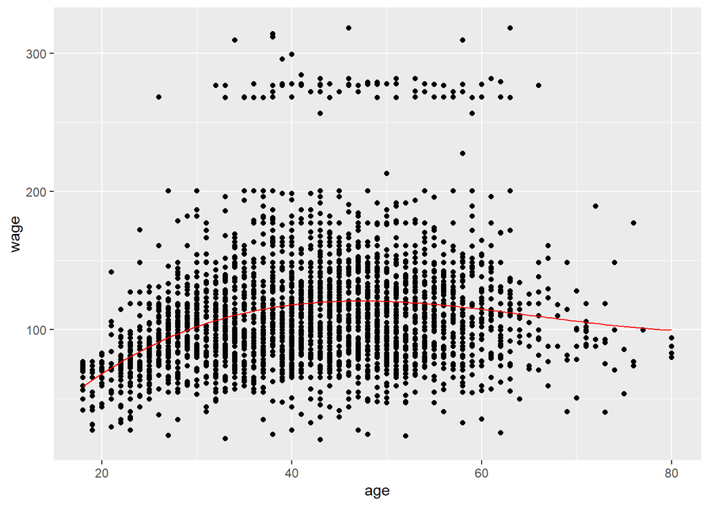

```r
age_grid <- seq(from=min(Wage$age),to=max(Wage$age),length.out=100)
age_grid_df <- tibble(age=age_grid)
age_grid_df$wage_predicted <- predict(lm_3,newdata=age_grid_df)

Wage %>%
  ggplot(aes(y=wage, x=age)) +
    geom_point() +
    geom_line(data=age_grid_df,
              mapping=aes(y=wage_predicted,x=age),
              color="red")
```

What do we note from this process?

The higher the order of the polynomial, the greater the flexibility in the model:
$$y=β0+β1x+β2x2+...+βpxp$$
A $pth$ order polynomial has $p+1$ different coefficients.

That flexibility is represented visually by an increased number of “turning points”. The linear/first order polynomial model resulted in a straight line with no turning points. The quadratic/second order polynomial model resulted in an “upside down u-shaped” curve with one turning point. The cubic/third order polynomial model results in a curve with two turning points.

Higher order polynomials are more flexible, allowing us to model more complicated relationships. Given what we’re seen in previous sessions, it hopefully doesn’t come as a surprise that the additional flexibility will at some point become a detriment – we will be overfitting.

## Twentieth order polynomial

We might progress on, up to something like a twentieth order polynomial model.

```r
summary(lm_3)$adj.r.squared
```

```
[1] 0.08418615
```

```r
lm_20 <- lm(wage~poly(age,20), data=Wage)
summary(lm_20)$adj.r.squared
```

```
[1] 0.08421218
```

```r
AIC(lm_3)
```

```
[1] 30642.92
```

```r
AIC(lm_20)
```

```
[1] 30659.77
```

```r
set.seed(1)
print(c(cv_3$cv,cv_3$se))
```

```
         CV          CV
39.95162176  0.01900926
```

```r
cv_20 <- cvFit(lm_20,data=Wage,y=Wage$wage,K=5,R=20)
print(c(cv_20$cv,cv_20$se))
```

```
        CV         CV
40.1488539  0.1297099
```

According to the adjusted $R2$ the twentieth order polynomial model is superior, while AIC and cross validation indicate that the third order polynomial model is superior. In such cases we can make arguments in favour of either of the two models, but might generally prefer to base our decision making on the cross validation results.

Where possible, it is always useful to plot the model.

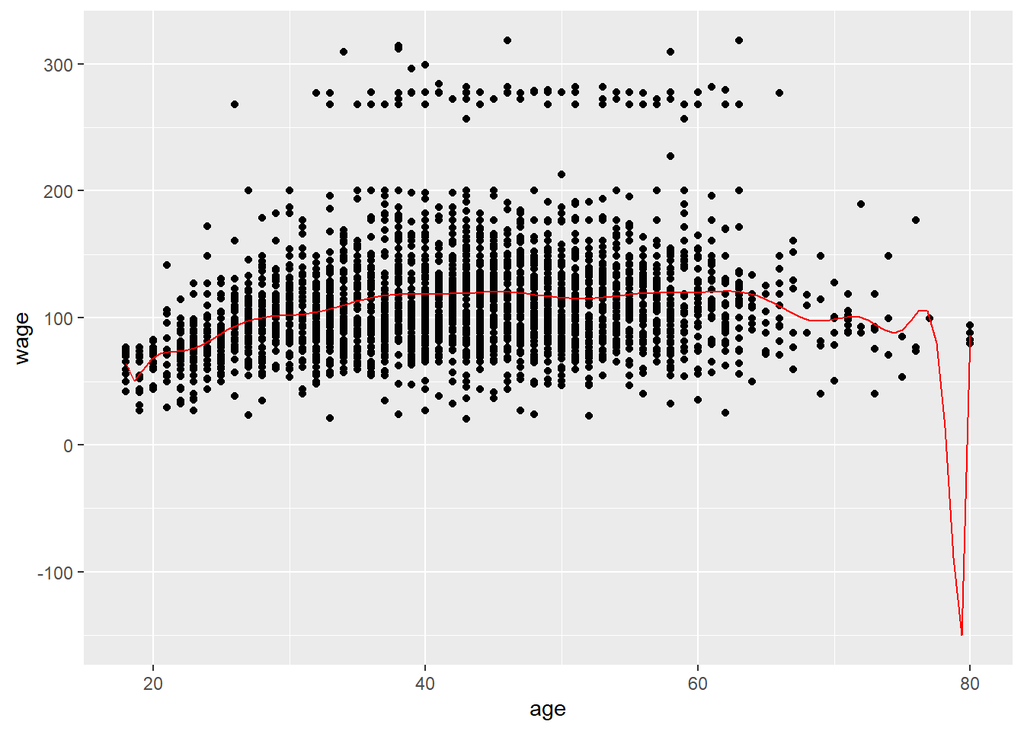

```r
age_grid <- seq(from=min(Wage$age),to=max(Wage$age),length.out=100)
age_grid_df <- tibble(age=age_grid)
age_grid_df$wage_predicted <- predict(lm_20,newdata=age_grid_df)

Wage %>%
  ggplot(aes(y=wage, x=age)) +
    geom_point() +
    geom_line(data=age_grid_df,
              mapping=aes(y=wage_predicted,x=age),
              color="red")
```

In doing so, we see some very wacky behaviour. This is not uncommon for polynomial models of higher degree.

The model is using the flexibility afforded to it to desperately fit even the observations at the extreme values of $x$. We have come across one of the pitfalls of polynomial models: observations at every value of $x$ have a direct impact on the coefficient estimates, and the coefficient values impact the prediction at every value of $x$. This can result in scenarios where, in an attempt to fit well at lower values of $x$, the model in turn produces very unusual results at higher values of $x$, and vice versa.

# Spline models

Polynomial models can suffer from the influence of every observation on the prediction at every value of $x$. We might work around this by fitting different models to different ranges of $x$.

Consider:
$$Y=β0,1+β1,1X+β2,1X2+β3,1X3+...+βp,1Xpfor X<X∗Y=β0,2+β1,2X+β2,2X2+β3,2X3+...+βp,2Xpfor X≥X∗$$

The breakpoint between the models, $X∗$, might then be referred to as a knot.

## Naive spline

Consider fitting a cubic polynomial model on each side of a single knot, where the knot is chosen to be at the median of the data.

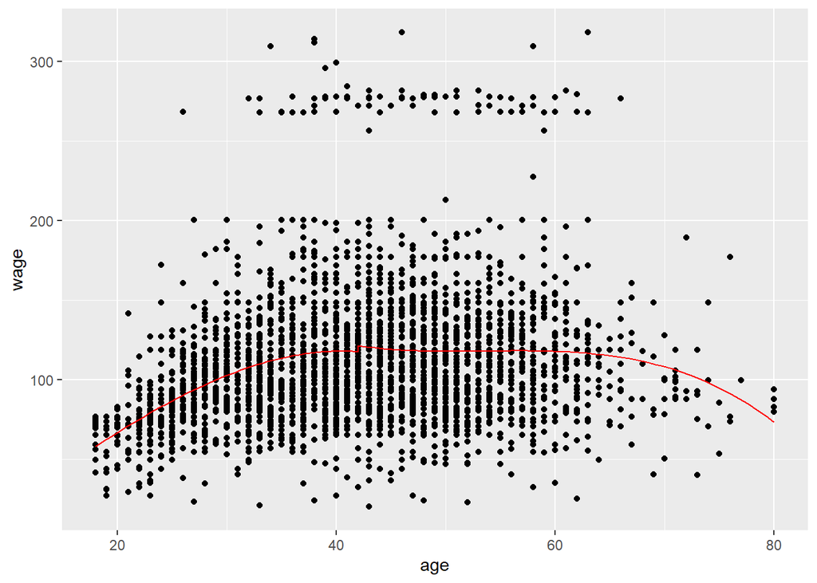

```r
Wage_left <- Wage[Wage$age<median(Wage$age),]
Wage_right <- Wage[Wage$age>=median(Wage$age),]

lm_3_left <- lm(wage~poly(age,3),data=Wage_left)
lm_3_right <- lm(wage~poly(age,3),data=Wage_right)

age_grid_left <- seq(min(Wage$age),median(Wage$age),l=50)
age_grid_df_left <- tibble(age=age_grid_left)
age_grid_df_left$wage_predicted <- predict(lm_3_left,newdata=age_grid_df_left)

age_grid_right <- seq(median(Wage$age),max(Wage$age),l=50)
age_grid_df_right <- tibble(age=age_grid_right)
age_grid_df_right$wage_predicted <- predict(lm_3_right,newdata=age_grid_df_right)

age_grid_df <- rbind(age_grid_df_left,age_grid_df_right)

Wage %>%
  ggplot(aes(y=wage,x=age)) +
    geom_point() +
    geom_line(data=age_grid_df,
              mapping=aes(y=wage_predicted,x=age),
              color="red")
```

There are two downsides to this type of model.

The first is the likelihood of a discontinuity at the knot. It is very likely that at the knot, the value of the left polynomial is not identical to the value of the right polynomial. Not only are the values of the polynomials likely to differ at the knot, the values of the derivatives (rates of change) of the polynomials are likely to differ at the knot.

Ideally, we would like continuity (of the fitted model and its derivatives) at the knot. In such cases we would not see a jump in the value of `wage` at a particular value of `age`, nor would we see one relationship of `wage` with `age` on one side of the knot and a dramatically different relationship on the other side of the knot.

The second downside is a rapid increase in model complexity. The code above includes a single knot and third order polynomials, leading to eight different coefficients (that is, the model has eight degrees of freedom).

If we were to add another knot then we would add another four coefficients. If we were to increase the degree of our polynomial by one, we would add a number of coefficients equal to the number of knots plus one.

All together, $k$ knots and polynomials of order $p$ results in a total of $(p+1)×(k+1)$ coefficients. Hopefully, this gives some insight that models like this one can quickly become highly flexible and in danger of overfitting.

## Basis splines

One way to avoid the problems encountered by the naive spline model above is to enforce constraints on the fitted coefficients. For example:
$$Y=β0,1+β1,1X+β2,1X2+β3,1X3for X<X∗Y=β0,2+β1,2X+β2,2X2+β3,2X3for X≥X∗$$
with the restrictions that:
$$β0,1+β1,1X∗+β2,1(X∗)2+β3,1(X∗)3=β0,2+β1,2X∗+β2,2(X∗)2+β3,2(X∗)3β1,1+2×β2,1X∗+3×β3,1(X∗)2=β1,2+2×β2,2X∗+3×β3,2(X∗)22×β2,1+6×β3,1X∗=2×β2,2+6×β3,2X∗$$

Those three constraints enforce equality in the functions, their first derivatives and their second derivatives at the knot. That ensures a degree of smoothness at the knot, resolving one of the concerns of the previous naive model.

The presence of these constraints reduces the flexibility of the model. Specifically, the three constraints reduce the degrees of freedom by three, resulting in a model with $(4×2)−3=5$ degrees of freedom. Extending this logic, a model of this form using $p$-dimensional polynomials constrained to agree up to and including the $(p−1)th$ derivative at $k$ knots will have a total of $p+1+k$ degrees of freedom. This is a dramatic reduction from the $(p+1)×(k+1)$ degrees of freedom of the previous naive model.

Programming up a model like this is non-trivial. Fortunately, there are some mathematical optimisations which we won’t get into here through which the above model can be represented through a more straightforward combination of basis spline, or b-spline, functions.

```r
library(splines)
```

It is possible to fit such models by specifying the knot locations.

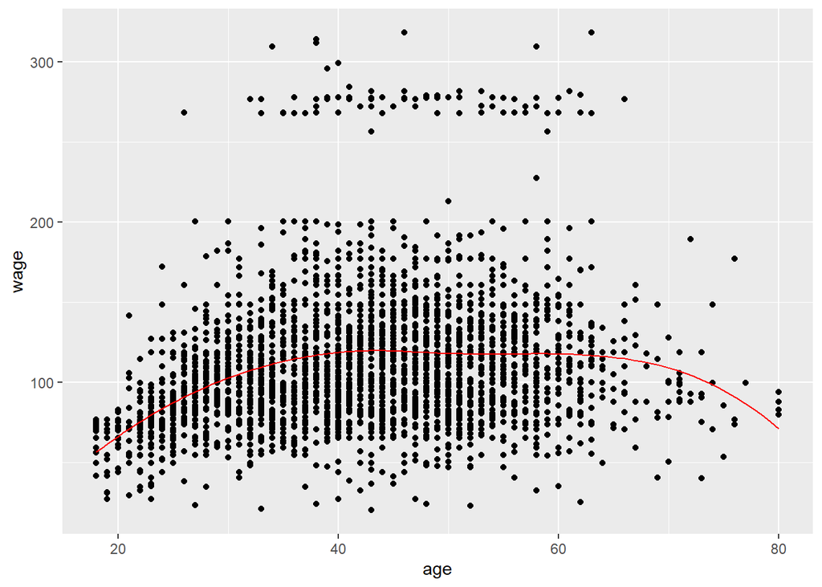

```r
fit_spline1 <- lm(wage~bs(age,knots=quantile(Wage$age,c(0.25,0.5,0.75))),data=Wage)

age_grid_df$wage <- predict(fit_spline1,newdata=age_grid_df)

ggplot(mapping=aes(y=wage,x=age)) +
  geom_point(data=Wage) +
  geom_line(data=age_grid_df,color="red")
```

Alternatively, it is possible to fit such models by specifying the desired degrees of freedom of the resulting model (the default is to use third order polynomials, but this can be modified via the `degree` argument to the `bs` function).

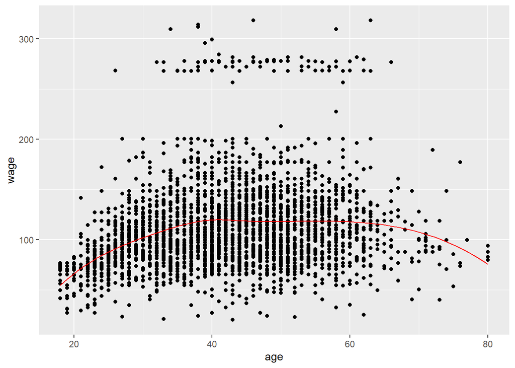

```r
fit_spline2 <- lm(wage~bs(age,df=7),data=Wage)

age_grid_df$wage <- predict(fit_spline2,newdata=age_grid_df)

ggplot(mapping=aes(y=wage,x=age)) +
  geom_point(data=Wage) +
  geom_line(data=age_grid_df,color="red")
```

This model with degrees of freedom $7$ is almost identical to the previous model with three knots, one at each of the lower quartile, median and upper quartile.

The somewhat local nature of the fitting process means that we may avoid the issues observed with higher order polynomial models. We previously considered a polynomial model of order $20$, which has $21$ degrees of freedom. Let us see how that compares to a spline model which also has $21$ degrees of freedom.

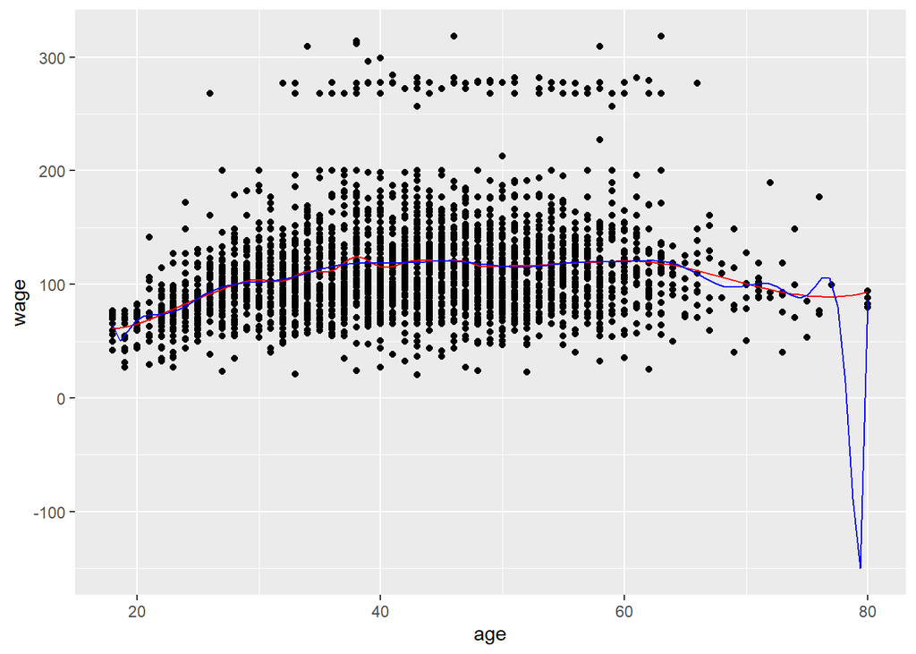

```r
fit_spline3 <- lm(wage~bs(age,df=21),data=Wage)

age_grid <- seq(from=min(Wage$age),to=max(Wage$age),length.out=100)
age_grid_df <- tibble(age=age_grid)

age_grid_df_poly <- age_grid_df
age_grid_df_poly$wage_predicted <- predict(lm_20,newdata=age_grid_df_poly)

age_grid_df_spline <- age_grid_df
age_grid_df_spline$wage_predicted <- predict(fit_spline3,newdata=age_grid_df_spline)

Wage %>%
  ggplot(aes(y=wage, x=age)) +
    geom_point() +
    geom_line(data=age_grid_df_spline,
              mapping=aes(y=wage_predicted,x=age),
              color="red") +
    geom_line(data=age_grid_df_poly,
              mapping=aes(y=wage_predicted,x=age),
              color="blue")
```

## Optimising degrees of freedom

We now have at our disposal a family of models, parameterised by the number of degrees of freedom. As we have seen previously, a degrees of freedom which is too small may unnecessarily limit the flexibility of the model and cause us to underfit, whereas a degrees of freedom which is too large may include unnecessary flexibility and cause us to overfit.

Quantifying the accuracy of predictions for test data using models fitted to training data is one way to identify the sweet spot between underfitting and overfitting. Cross validation is one way to achieve this.

```r
set.seed(2)

n <- nrow(Wage)

df_vals <- 4:25

n_vals <- length(df_vals)

results <- data.frame(df = rep(0,n_vals),
                      rmse_training = rep(0,n_vals),
                      rmse = rep(0,n_vals),
                      se = rep(0,n_vals))

for (i in 1:n_vals){

  df_i <- df_vals[i]

  fit_spline <- lm(wage~bs(age,df=df_i),data=Wage)

  cv_result <- cvFit(fit_spline, data = Wage,y = Wage$wage, K = 10, R = 10)

  results$df[i] <- df_i
  results$rmse[i] <- cv_result$cv
  results$se[i] <- cv_result$se

  wage_pred <- predict(fit_spline)
  rmse_train <- sqrt(sum((Wage$wage - wage_pred)^2)/n)
  results$rmse_training[i] <- rmse_train

}

print(results)
```

```
   df rmse_training     rmse         se
1   4      39.88776 39.94628 0.01311033
2   5      39.85963 39.91886 0.01568479
3   6      39.85910 39.94389 0.01466024
4   7      39.85545 39.93987 0.01134205
5   8      39.84790 39.95229 0.01116237
6   9      39.83510 39.95657 0.01118467
7  10      39.80791 39.92937 0.01392969
8  11      39.80054 39.94934 0.02726817
9  12      39.80416 39.95177 0.02153801
10 13      39.79343 39.96536 0.01982667
11 14      39.79796 39.96373 0.01885337
12 15      39.79264 39.98827 0.01805339
13 16      39.78729 39.98454 0.03088121
14 17      39.78594 40.00724 0.02910332
15 18      39.77416 40.02549 0.02323501
16 19      39.78367 40.02979 0.02055627
17 20      39.77126 40.03337 0.03875378
18 21      39.76730 40.03326 0.03142320
19 22      39.76191 40.04680 0.02515775
20 23      39.76264 40.06666 0.04136160
21 24      39.75527 40.08028 0.04552543
22 25      39.74032 40.06554 0.03404295
```

We may visualise how the error for the training and test datasets varies with the number of degrees of freedom.

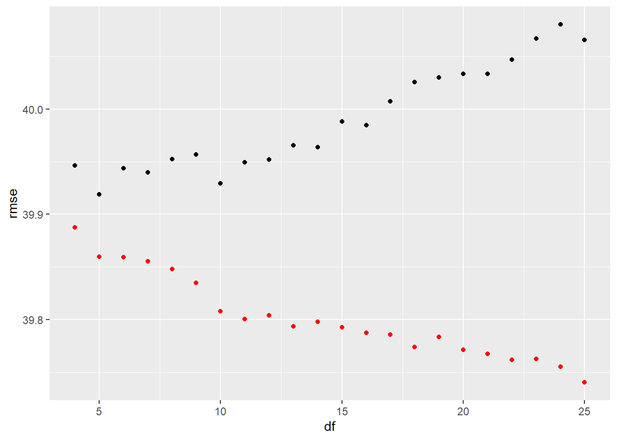

```r
ggplot(data=results) +
  geom_point(mapping=aes(x=df, y=rmse)) +
  geom_point(mapping=aes(x=df, y=rmse_training), color="red")
```

We may also visualise how the test error obtained via cross validation varies after incorporating the variability in the test error using different numbers of knots.

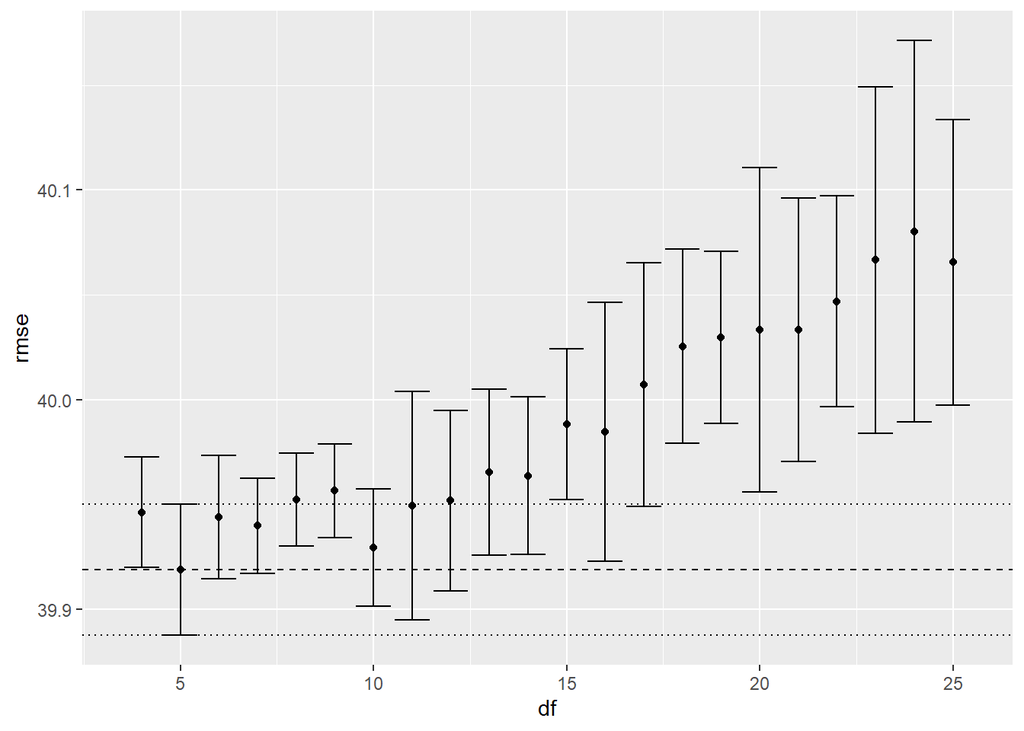

```r
best_rmse <- min(results$rmse)
best_row <- which.min(results$rmse)
best_df <- results$df[best_row]
best_se <- results$se[best_row]

ggplot(data=results) +
  geom_point(mapping=aes(x=df, y=rmse)) +
  geom_errorbar(mapping=aes(x=df, ymin=rmse-2*se, ymax=rmse+2*se)) +
  geom_hline(yintercept = best_rmse, linetype="dashed") +
  geom_hline(yintercept = best_rmse+2*best_se, linetype="dotted") +
  geom_hline(yintercept = best_rmse-2*best_se, linetype="dotted")
```

To identify the best overall model, we first consider the model with the lowest cross validation error. In this case, that is the model with five degrees of freedom.

We generally aim for parsimony – using the least complicated model we can get away with. As a result, we would make the decision to put forwards the model with four degrees of freedom as our best model in this case – it is the least complicated model which has error which is indistinguishable from the model with the very lowest error.

# Local regression

Recall, splines were useful because the fitted function at some value of $x$ was largely determined by other observations near $x$ (those observations between the same two knots that $x$ itself fell between), as opposed to by observations at all other values of $x$. An alternative is a class of models referred to as local regression (shortened to loess or lowess depending upon the exact methodology followed).

It isn’t important for us to know the precise details of these methodologies, but more information can be found in Section 7.6 of the [ISLR](https://www.statlearning.com/) textbook. In short, they fit the model at a given value of $x$ by minimising the weighted sum of squares of residuals in the neighbourhood of $x$.

The weighting function applies full weight to values at $x$, falling to zero as we move further away from $x$. The rate at which the weight function decays is inversely related to what is called the `span` by the R function `loess`.

A large span means a slow decay in the weights, meaning that a wider range of observations contribute to the fit at $x$, meaning that the fitted function is less flexible, and thus there may be the potential for underfitting. A small span means a fast decay in the weights, meaning that a narrower range of observations contribution to the fit at $x$, meaning that the fitted function is more flexible, and thus that there may be the potential for overfitting. This flexibility can be summarised by an effective degrees of freedom measurement, and as you might expect cross validation may be tool to find an optimal span.

```r
fit_loess1 <- loess(wage~age,span=.2,data=Wage)
fit_loess2 <- loess(wage~age,span=1,data=Wage)

summary(fit_loess1)
```

```
Call:
loess(formula = wage ~ age, data = Wage, span = 0.2)

Number of Observations: 3000
Equivalent Number of Parameters: 16.42
Residual Standard Error: 39.92
Trace of smoother matrix: 18.15  (exact)

Control settings:
  span     :  0.2
  degree   :  2
  family   :  gaussian
  surface  :  interpolate     cell = 0.2
  normalize:  TRUE
 parametric:  FALSE
drop.square:  FALSE
```

```r
summary(fit_loess2)
```

```
Call:
loess(formula = wage ~ age, data = Wage, span = 1)

Number of Observations: 3000
Equivalent Number of Parameters: 3.37
Residual Standard Error: 39.94
Trace of smoother matrix: 3.57  (exact)

Control settings:
  span     :  1
  degree   :  2
  family   :  gaussian
  surface  :  interpolate     cell = 0.2
  normalize:  TRUE
 parametric:  FALSE
drop.square:  FALSE
```

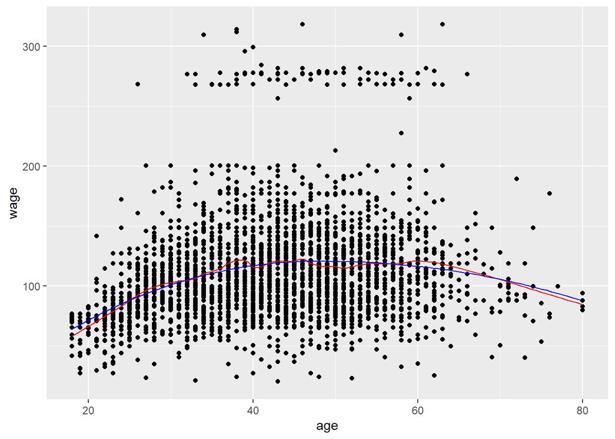

```r
age_grid_df_l1 <- age_grid_df
age_grid_df_l2 <- age_grid_df

age_grid_df_l1$wage <- predict(fit_loess1, newdata = age_grid_df_l1)
age_grid_df_l2$wage <- predict(fit_loess2, newdata = age_grid_df_l2)

ggplot(mapping=aes(y=wage, x=age)) +
  geom_point(data=Wage) +
  geom_line(data=age_grid_df_l1, color="red") +
  geom_line(data=age_grid_df_l2, color="blue")
```

# Interpretability

One aim of model building is to make accurate predictions. In such cases, the interpretability of the model may be downplayed or ignored entirely.

In other cases, we might aim to gain some understanding of how $x$ influences $y$. In such cases, it might be nice to have a single equation summarising that relationship.

Consider the polynomial regression model, where there is one single equation which defines the predictions for every single value of $x$. Next, consider the spline model, where there are $k+1$ equations which define predictions, one equation for each between-knot range. Finally, consider the locally weighted regression model, where there is essentially a different equation at every unique value of $x$.

Of course, it is natural to question whether the polynomial regression equation is itself actually all that interpretable. In the case of our degree twenty polynomial model it is impossible to make a simple statement along the lines of “as $x$ increases by $1$, $y$ changes by $z$” because of the nonlinearity of polynomials of degree greater than one.